# Linear Discriminant Analysis - Email vs. Spam

C. H. Chiu

2018年7月19日

## Introduction

The dataset ‘spambase’ derives from a collection of spam e-mails and non-spam e-mails. Most of the variables indicate whether a particularwordd or character was frequently occurring in the e-mail. A class variable ‘class’ determines whether the observation is classfied as ‘spam’ or normal ‘email’.

In this document we’re applying linear discriminant analysis for this binary classification problem.

## Analysis

### Preparation

We load a few packages before we start the analysis:

- data.table, dplyr: dataset manipulations
- ggplot2: graphs
- caret, MASS: linear discriminant analysis and cross-validation
- plotROC: ROC curve

```r
library(data.table)
library(dplyr)
library(MASS)
library(caret)
library(ggplot2)
library(plotROC)
```

### Load in the data

We use fread() function from ‘data.table’ library to read in our dataset.

```r
spamtest = fread('spambase.txt')
setDT(spamtest)
dim(spamtest)
```

```
## [1] 4601   63
```

As we see there are 4601 rows and 63 variables in this dataset.

### Correlations

Collinearity among variables could be harmful for multivariate analysis. We may identify if there are highly correlated or even identical variables in the datasets. In the following section, we’re actually able to find 2 sets of identical variables (4 variables in total) and remove them from the datasets.

```r
cor = cor(spamtest[, sapply(spamtest, is.numeric), with = F], method = 'pearson')
cor.column = which(cor > 0.99999, arr.ind = T)[which(cor > 0.99999, arr.ind = T)[,1]!=which(cor > 0.99999, arr.ind = T)[,2],]
spamtest[,rownames(cor.column):=NULL]
```

### Split into training and testing sets

We split 70% of the rows as the training the set with the rest of 30% as the testing set.

```r
split = 0.7
index = sample(nrow(spamtest), round(nrow(spamtest)*split))
spam.train = spamtest[index]
spam.test  = spamtest[-index]
```

### Exploratory analysis

```r
spam.train %>% sapply(class)
```

```
##        make     address         all          xd         our        over
##   "numeric"   "numeric"   "numeric"   "numeric"   "numeric"   "numeric"
##      remove    internet       order        mail     receive        will
##   "numeric"   "numeric"   "numeric"   "numeric"   "numeric"   "numeric"
##      people      report   addresses        free    business       email
##   "numeric"   "numeric"   "numeric"   "numeric"   "numeric"   "numeric"
##         you      credit        your        font        x000       money
##   "numeric"   "numeric"   "numeric"   "numeric"   "numeric"   "numeric"
##          hp         hpl      george        x650         lab        labs
##   "numeric"   "numeric"   "numeric"   "numeric"   "numeric"   "numeric"
##      telnet        x857        data        x415         x85  technology
##   "numeric"   "numeric"   "numeric"   "numeric"   "numeric"   "numeric"
##       x1999       parts          pm      direct          cs     meeting
##   "numeric"   "numeric"   "numeric"   "numeric"   "numeric"   "numeric"
##    original     project          re         edu       table  conference
##   "numeric"   "numeric"   "numeric"   "numeric"   "numeric"   "numeric"
##          x.         x..       x...1        x..1        x..2        x..3
##   "numeric"   "numeric"   "numeric"   "numeric"   "numeric"   "numeric"
##        crla        crll        crrt       class          V1
##   "numeric"   "integer"   "integer" "character"   "integer"
```

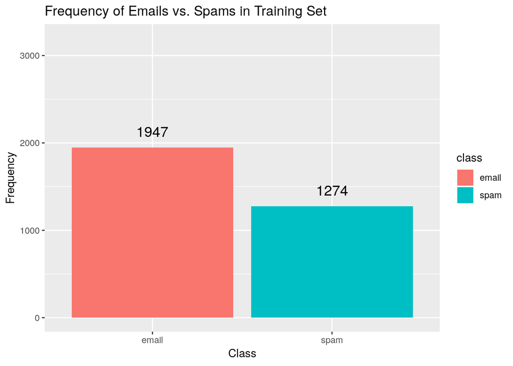

```r
ggplot(spam.train, aes(x = class, fill=class)) +
  geom_bar() +
  stat_count(aes(label=..count..), geom="text", vjust=-1, size=5) +
  labs(title='Frequency of Emails vs. Spams in Training Set', y='Frequency', x='Class') + ylim(c(0, 3200))
```

We check the basic descriptive statistics for every variables and make a plot of the frequency of each class. As mentioned earlier, only one character variable, which is the class variable, exists and the rest are all numeric. We then examine if the label is imbalanced by using the barplot. If the label is very imbalanced, we may have to consider other metrics other than accuracy to correctly evaluate the model. Fortunately though, the distribution doesn’t seem so imbalanced.

### Linear discriminant analysis

We use the training function from ‘caret’ package for our linear discriminant analysis. Alongside the LDA, 10-fold cross validation is also used to improve the model.

```r
ctrl = trainControl(method="cv", summaryFunction=twoClassSummary, classProbs=T, savePredictions = T)
lda.fit = train(class ~ ., data = spam.train, method = "lda", trControl = ctrl)
summary(lda.fit)
```

```
##             Length Class      Mode
## prior         2    -none-     numeric
## counts        2    -none-     numeric
## means       116    -none-     numeric
## scaling      58    -none-     numeric
## lev           2    -none-     character
## svd           1    -none-     numeric
## N             1    -none-     numeric
## call          3    -none-     call
## xNames       58    -none-     character
## problemType   1    -none-     character
## tuneValue     1    data.frame list
## obsLevels     2    -none-     character
## param         0    -none-     list
```

### Prediciton and accuracy

```r
lda.pred = predict(lda.fit, spam.test)
actual.value = factor(spam.test$class)
conf_matrix = confusionMatrix(lda.pred, actual.value, positive = 'spam')
conf_matrix$table
```

```
##           Reference
## Prediction email spam
##      email   814  108
##      spam     27  431
```

```r
conf_matrix$overall[1]
```

```
##  Accuracy
## 0.9021739
```

### Sensitivity, Specificity and ROC curve

```r
conf_matrix$byClass[1:2]
```

```
## Sensitivity Specificity
##   0.7996289   0.9678954
```

Accuracy is sort of a balance between sensitivity and specificity. In the spam mail case, we generally want to evaluate how good the spam mails can be correctly identified. Whether the non-spam emails can be correctly identified as non-spam is usually not our top concern. Sensitivity above shows how good the model can identify the spam mails while specificity is for non-spam emails. From above, we can clearly see the current model actually classifies non-spam mails better than spam mails.

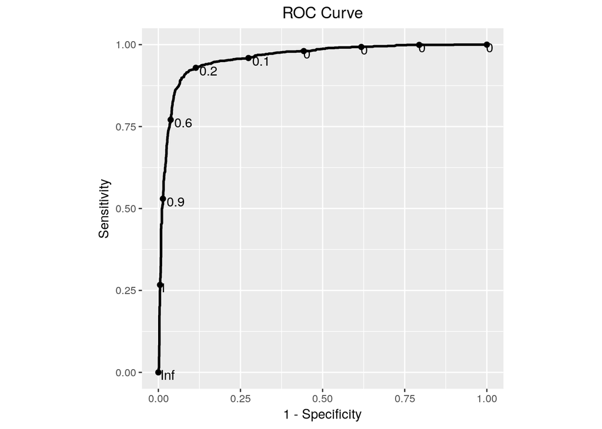

```r
roc.plot = ggplot(lda.fit$pred, aes(m = spam, d = factor(obs, levels = c('spam', 'email')) )) +
  geom_roc(hjust = -0.4, vjust = 1.5) + coord_equal() +
  xlab('1 - Specificity') + ylab('Sensitivity') +
  labs(title='ROC Curve') + theme(plot.title = element_text(hjust = 0.5))
roc.plot
```

```r
calc_auc(roc.plot)[3]
```

```
##         AUC
## 1 0.9586326
```

If we construct a ROC curve and calculate the area under curve (AUC), 95% is actually not a bad result for AUC. This is due to the nature that ROC curve takes both sensitivity and specificity into consideration. In our case while the sensitivity of the current model is around 80% (4 out of 5 spam mails can be correctly identified), the specificity on the other hand is around 97%, very close to 100%.

## Conclusion

To evaluate the effectiveness of model, we need to determine what goal we want to achieve beforehand. In conclusion, if the user is trying to identify as many spam mails as possible, then it is suggested to try different classifiers since 80% of sensitivity might not be enough. On the other hand, if the user wants to avoid non-spam emails wrongly classifed as spams, 97% of specificity from the current model is actually a very viable choice.